# R语言绘图：POC与MAOC关系分析

## 1. 引言

本文档旨在分析土壤有机碳（SOC）组分，特别是颗粒有机碳（POC）和矿物相关有机碳（MAOC）之间的关系，并探讨其与干旱指数（Aridity）的相关性。分析基于`Soil_C_fractions.xlsx`数据集，并使用R语言的`ggplot2`包进行可视化。

## 2. 数据描述

本次分析使用的数据来源于`Soil_C_fractions.xlsx`文件。其中，我们关注以下几个关键变量：

- **POC (g kg⁻¹)**: 颗粒有机碳含量，表示土壤中以颗粒态存在的有机碳。
- **MAOC (g kg⁻¹)**: 矿物相关有机碳含量，表示与土壤矿物紧密结合的有机碳。
- **Aridity**: 干旱指数，用于衡量区域的干旱程度，在本分析中用作区分不同样本的颜色变量。

## 3. 数据准备

首先，加载所需的R包，并读取`Soil_C_fractions.xlsx`文件。随后，筛选出分析所需的列：`ID`, `POC`, `MAOC`, `Aridity`。

```r
# 加载必要的R包
library(tidyverse)
library(readxl)
library(scales)
library(viridis)
library(gglmannotate)

# 读取数据
df <- read_xlsx(path = "Soil_C_fractions.xlsx", col_names = TRUE)

# 选择需要的列：ID, POC, MAOC, Aridity
df_sub <- df %>% dplyr::select(ID, POC, MAOC, Aridity)

# 查看数据前几行
head(df_sub)
```

```
## # A tibble: 6 × 4
##      ID   POC  MAOC Aridity
##   <dbl> <dbl> <dbl>   <dbl>
## 1     1  1.83  4.85   0.830
## 2     2  1.13  2.61   0.832
## 3     3  2.81  5.17   0.832
## 4     4  3.50  5.08   0.851
## 5     5  1.66  2.67   0.851
## 6     6  3.10  2.25   0.852
```

## 4. 绘图代码与过程

使用`ggplot2`绘制POC与MAOC的散点图，并根据Aridity进行着色。同时，添加线性拟合曲线、y=x参考线以及对数刻度。

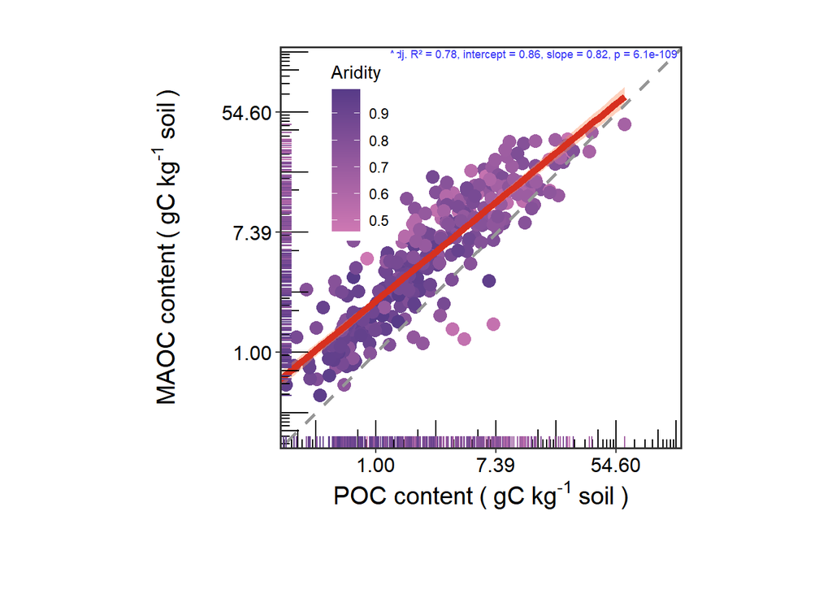

```r
# 确定 x 和 y 的最大范围
max_range <- max(df_sub$POC, df_sub$MAOC, na.rm = TRUE) + 100
min_range <- min(df_sub$POC, df_sub$MAOC, na.rm = TRUE)

# 使用ggplot2绘制散点图和线性拟合曲线
p1 <- df_sub %>%
  ggplot(aes(x = POC, y = MAOC)) +
  geom_point(aes(color = Aridity), size = 3.5) +  # 根据Aridity着色的散点图
  geom_smooth(method = "lm", color = "#d7301f", fill = "#fc8d59", linewidth = 2) +  # 线性拟合曲线
  geom_abline(slope = 1, intercept = 0, linewidth = 1, linetype = 2, color = "#969696") +  # 添加y=x的参考线
  scale_y_continuous(trans = log_trans(),  # y轴对数变换
                     labels = function(x) number(x, accuracy = 0.01),  # y轴标签格式化
                     expand = c(0, 0),  # 去除y轴扩展
                     limits = c(min_range, max_range)) +  # 设置y轴范围
  scale_x_continuous(trans = log_trans(),  # x轴对数变换
                     labels = function(x) number(x, accuracy = 0.01),  # x轴标签格式化
                     expand = c(0, 0),  # 去除x轴扩展
                     limits = c(min_range, max_range)) +  # 设置x轴范围
  annotation_logticks(sides = "bl", outside = FALSE,  # 添加对数刻度线
                      short = unit(0.2, "cm"),
                      mid = unit(0.4, "cm"),
                      long = unit(0.6, "cm")) +
  geom_rug(aes(color = Aridity), length = unit(0.03, "npc")) +  # 添加边缘线
  geom_lmannotate(colour = "#3635F6") + # 添加拟合参数注释
  scale_color_gradient(low = "#CE78B3FF",high = "#573B88FF")+ # 设置颜色映射
  labs(x = expression(atop("POC content"~paste("(",~"gC",~"kg"^"-1",~"soil",~")"))),  # 自定义x轴标签
       y = expression(atop("MAOC content"~paste("(",~"gC",~"kg"^"-1",~"soil",~")")))) +  # 自定义y轴标签
  theme_bw() +  # 使用白色背景主题
  theme(axis.text.x = element_text(size = 12, color = "#000000"),  # 自定义轴文本样式
        axis.text.y = element_text(size = 12, color = "#000000"),
        axis.title = element_text(size = 15, color = "#000000"),
        plot.title = element_text(size = 20, color = "#000000", hjust = 0.5),
        panel.grid = element_blank(),  # 移除网格线
        plot.margin = margin(t = 1, r = 1, b = 1, l = 1, unit = "cm"),  # 设置绘图边距
        aspect.ratio = 1,  # 设置绘图宽高比
        legend.position = c(0.2, 0.75),  # 设置图例位置
        panel.border = element_rect(linewidth = 1))  # 添加面板边框

# 显示图形
print(p1)
```

```r
# 保存绘图结果为PDF文件 (取消注释以启用)
# ggsave(filename = "linear fitting curve1.pdf",
#        family = "serif",
#        plot = p1,
#        height = 8,
#        width = 8)
```

## 5. 注意要点

- **数据文件**: 确保`Soil_C_fractions.xlsx`文件位于正确的路径下，以便R能够读取。
- **对数坐标轴**: 绘制时对POC和MAOC使用了对数坐标轴，这对于处理数值范围较大的数据非常有用。请注意对数轴的刻度表示。
- **Aridity变量**: 图中点的颜色代表了`Aridity`值，可以帮助我们观察干旱程度对POC和MAOC关系的影响。
- **线性拟合**: `geom_smooth(method = "lm")`添加了线性回归线，`geom_lmannotate()`则在图上直接标注了拟合的统计信息（如R²值、p值等），方便快速解读。
- **y=x参考线**: 添加的虚线代表y=x，用于直观比较POC和MAOC的相对大小。当POC和MAOC值相等时，点会落在该线上。
- **图例位置**: 图例被放置在图的左上角（c(0.2, 0.75)），以避免遮挡主要数据点。